# What Makes Riddles Hard

Maria Podryadchikiva, Anastasia Lisitsyna

June 21, 2019

```r
library(extrafont)
```

```r
library(ggplot2)
library(dplyr)
library(gridExtra)
library(GGally)
library(ggfortify)
```

**Here is project description** The aim of this study is analysing the linguistic features of “What? Where? When?” quiz questions (hereinafter ChGK-questions) of various difficulty. We suppose that it is possible to predict the difficulty of ChGK question set based on its linguistic features, including readability features and lexical peculiarities.

Although different quizzes are quite popular in the community of linguists, we have never heard of researches concerning the texts of quiz questions. We hope that our research can be interesting for both Digital Humanities admirers and quiz players.

**Data collection**  
To collect data, we have used Rating MAK (https://rating.chgk.info/) and ChGK Database (https://db.chgk.info) — the official resources of ChGK community, which provide the information of recent tournaments.

Pre-processing of the data was implemented with Python (BeautifulSoup, pandas, numpy). We downloaded and parsed 210 ChGK question sets, 70 for each difficulty category (easy, medium and hard). Then we calculated required variables for each of our sets. Clean dataset can be found here: https://raw.githubusercontent.com/laidhimonthegreen/chgk_R_project/master/chgk_df.csv

**Some variables of interest:**

dependent:  
* (additional) `dif_number`: difficulty value set by Rating MAK (on the scale from 0 to 10);  
* (main) `dif_level`: difficulty level set by the expert, a factor with levels `easy`, `medium`, `hard` (“easy” for 0-3.5, “medium” for 3.6-5.0, “hard” for 5.1-10.0);

independent:  
* `means_len`: mean of length of all questions of the set in chars;  
* `fk_mean`: the Flesch–Kincaid readability score, mean for the questions in the set  
* `often_w`: percentage of the words with high frequency (5 and higher) in the question set  
* `often_aw`: percentage of the words with high frequency (5 and higher) in the answers set  
* `often_n`: percentage of the nouns with high frequency (5 and higher) in the question set  
* `often_an`: percentage of the nouns with high frequency (5 and higher) in the answers set  
* `slang`: percentage of some ChGK cliches (“ИКС”, “АЛЬФА”, “ПРОПУСК”) in the question set

**Hypotheses** `добавила, чтобы у читающего сразу было понимание, что мы исследуем`

We will analyse the connection between dependent variable dif_level and following independent variables:

means_len:  
H0: The difficulty of the set is not related to the length of sentences  
H1: The difficulty of the set is higher with a higher length.  
`Something simple for warming up — is it possible that hard questions are longer than easy ones?`

fk_mean:  
H0: The difficulty of the set is not related to the readability metric.  
H1: The difficulty of the set is related to the readability metric.  
`Readability metrics are widely used for analysis of text difficulty. Can they be connected with the difficulty of quiz questions?`

often_w, often_n:  
H0: The difficulty of the set is not related to the frequency of “often” words in the questions.  
H1: The difficulty of the set is lower with a higher frequency of “often” words in the questions.  
`Lexical features: is the language of simple questions uses more frequent words?`

often_aw, often_an:  
H0: The difficulty of the set is not related to the frequency of “often” words in the answers  
H1: The difficulty of the set is higher with a higher frequency of “often” words in the answers  
`Is is possible that "simple words" occurs more often for simple questions?`

slang:  
H0: The difficulty of the set is not related to the amount of ChGK cliches in the questions.  
H1: The difficulty of the set is related to the amount of ChGK cliches in the questions.  
`Sometimes the authors of easy question sets try to avoid cliches to attract new players. Can we find any dependencies in our corpus?`

In general, we suppose that lexical features would be more important that readability and question lengths.

**1.0**

Load data:

```r
df <- read.csv("https://raw.githubusercontent.com/laidhimonthegreen/chgk_R_project/master/chgk_df.csv", sep="\t")
```

Reorganizing dif_level to follow from easy to hard

```r
df$levels = factor(df$dif_level,levels=levels(df$dif_level)[c(1,3,2)])
```

# 1 Descriptive statistics

**1.1**

The corpus is balanced.

```r
df %>% group_by(levels) %>%
  summarise(count=n())
```

| levels | count |
| --- | --- |
| easy | 70 |
| medium | 70 |
| hard | 70 |

**1.2** Analysing the distribution of data.

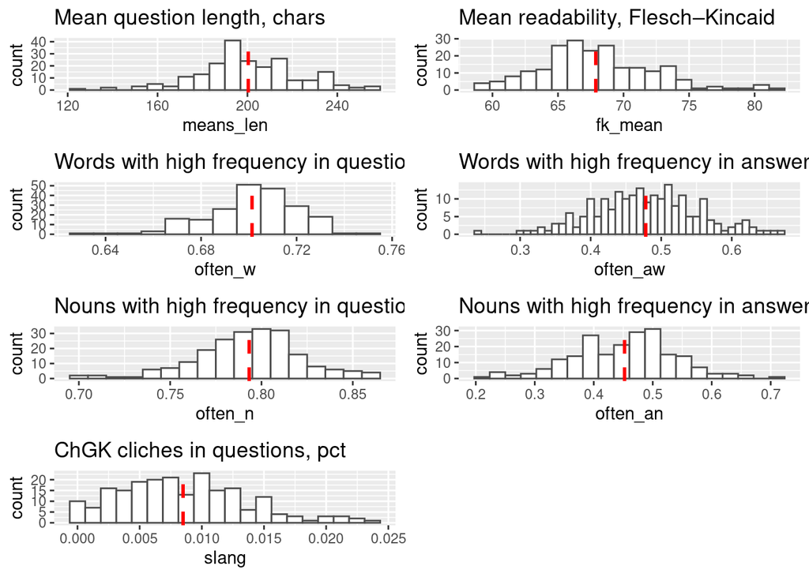

```r
hist_l<-
  ggplot(df, aes(x = means_len)) +
    geom_histogram(color = "grey30", fill = "white", bins=20) +
    ggtitle("Mean question length, chars") +
    geom_vline(data= df, aes(xintercept=mean(means_len)),
               linetype="dashed", size=1, colour="red")

hist_fk <-
  ggplot(df, aes(x = fk_mean)) +
    geom_histogram(color = "grey30", fill = "white", bins=20) +
    ggtitle("Mean readability, Flesch–Kincaid") +
    geom_vline(data = df, aes(xintercept=mean(fk_mean)),
               linetype="dashed", size=1, colour="red")

hist_ow <-
  ggplot(df, aes(x = often_w)) +
    geom_histogram(color = "grey30", fill = "white", binwidth=0.01) +
    ggtitle("Words with high frequency in questions, pct") +
    geom_vline(data=df, aes(xintercept=mean(often_w)),
               linetype="dashed", size=1, colour="red")

hist_aw <-
    ggplot(df, aes(x = often_aw)) +
    geom_histogram(color = "grey30", fill = "white", binwidth=0.01) +
    ggtitle("Words with high frequency in answers, pct") +
    geom_vline(data=df, aes(xintercept=mean(often_aw)),
               linetype="dashed", size=1, colour="red")

hist_on <-
    ggplot(df, aes(x = often_n)) +
    geom_histogram(color = "grey30", fill = "white", binwidth=0.01) +
    ggtitle("Nouns with high frequency in questions, pct") +
    geom_vline(data=df, aes(xintercept=mean(often_n)),
               linetype="dashed", size=1, colour="red")

hist_an <-
    ggplot(df, aes(x = often_an)) +
    geom_histogram(color = "grey30", fill = "white", bins=20) +
    ggtitle("Nouns with high frequency in answers, pct") +
    geom_vline(data=df, aes(xintercept=mean(often_an)),
               linetype="dashed", size=1, colour="red")

hist_slang <-
    ggplot(df, aes(x = slang)) +
    geom_histogram(color = "grey30", fill = "white", bins=20) +
    ggtitle("ChGK cliches in questions, pct") +
    geom_vline(data=df, aes(xintercept=mean(slang)),
               linetype="dashed", size=1, colour="red")

grid.arrange(hist_l, hist_fk, hist_ow, hist_aw, hist_on, hist_an, hist_slang, ncol=2)
```

We can see that the distributions of some of our variables are quite close to the normal distribution.

**1.3** Summary statistics.

```r
df %>% group_by(levels) %>%
  summarise(len=signif(mean(means_len), digits=3),
           fk=signif(mean(fk_mean), digits=2),
           often_w=signif(mean(often_w), digits=2),
           often_aw=signif(mean(often_aw), digits=2),
           often_n=signif(mean(often_n), digits=2),
           often_an=signif(mean(often_an), digits=2),
           slang=signif(mean(slang), digits=2))
```

| levels | len | fk | often_w | often_aw | often_n | often_an | slang |
| --- | --- | --- | --- | --- | --- | --- | --- |
| easy | 200 | 68 | 0.7 | 0.51 | 0.79 | 0.49 | 0.0083 |
| medium | 203 | 67 | 0.7 | 0.48 | 0.80 | 0.45 | 0.0094 |
| hard | 198 | 68 | 0.7 | 0.45 | 0.79 | 0.42 | 0.0078 |

So, we can see that there are almost no difference between mean values for most variables.

# 2 Do the sets of different difficulty differ?

**2.1** Let us take a look at boxplots for these variables.

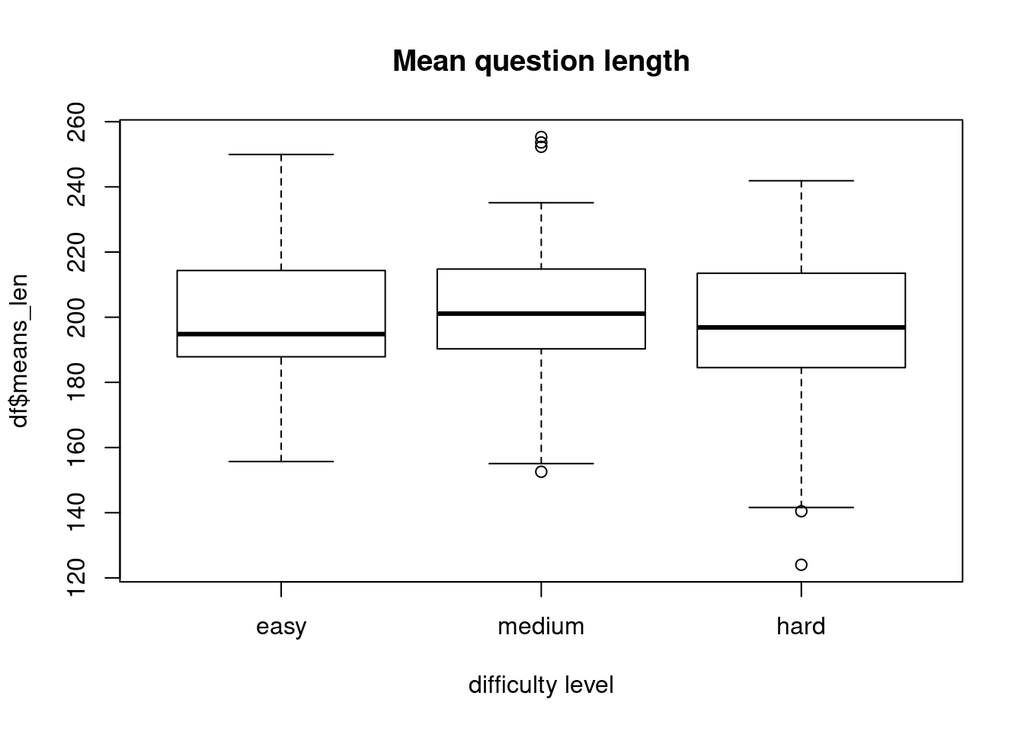

```r
boxplot(df$means_len ~ df$levels,
        main="Mean question length", xlab="difficulty level")
```

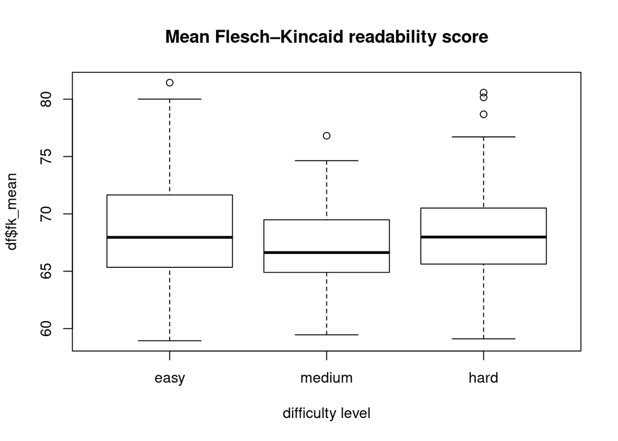

```r
boxplot(df$fk_mean ~ df$levels,
        main="Mean Flesch–Kincaid readability score", xlab="difficulty level")
```

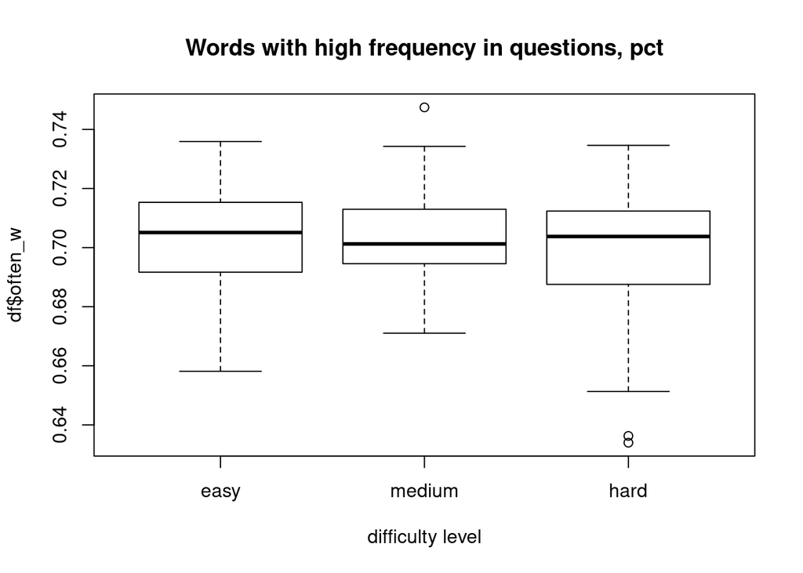

```r
boxplot(df$often_w ~ df$levels,
        main="Words with high frequency in questions, pct", xlab="difficulty level")
```

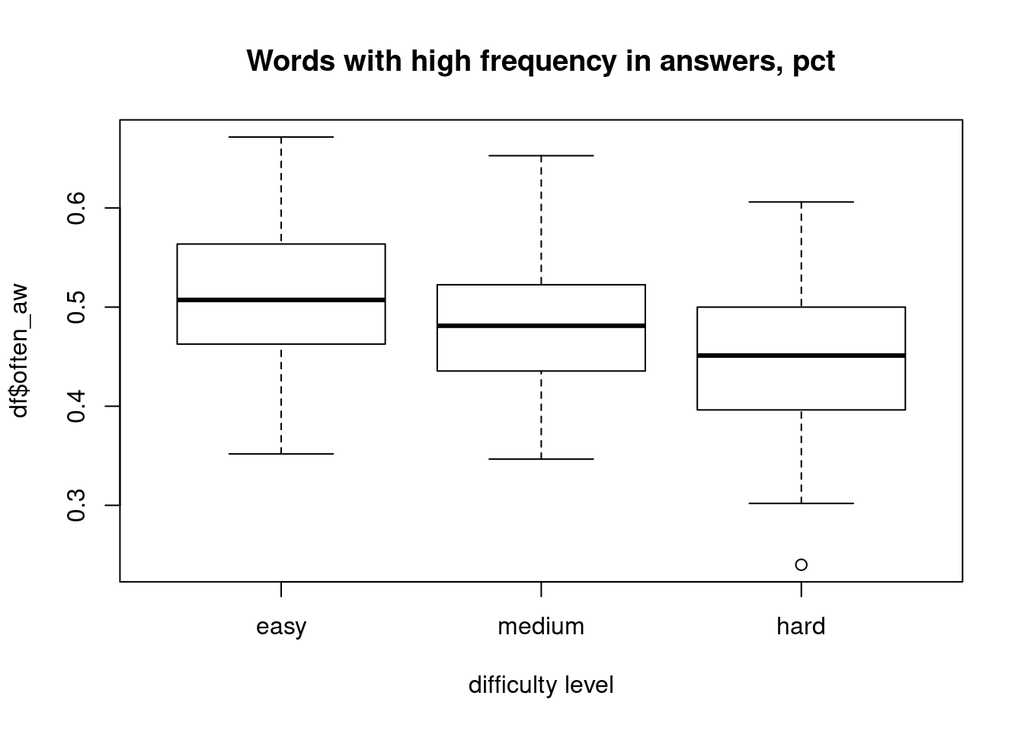

```r
boxplot(df$often_aw ~ df$levels,
        main="Words with high frequency in answers, pct", xlab="difficulty level")
```

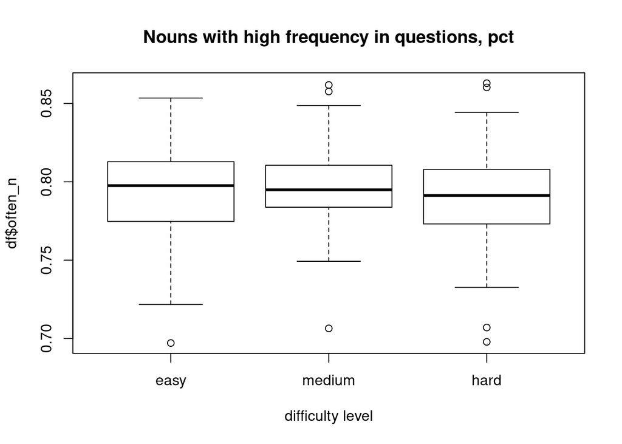

```r
boxplot(df$often_n ~ df$levels,
        main="Nouns with high frequency in questions, pct", xlab="difficulty level")
```

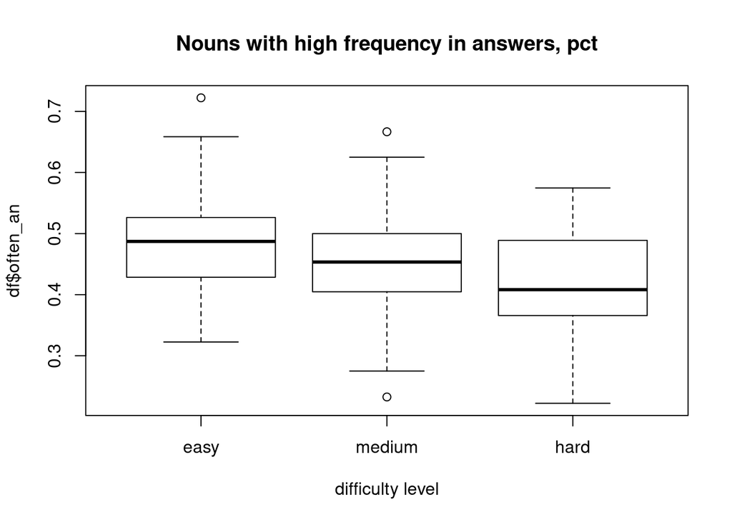

```r
boxplot(df$often_an ~ df$levels,
        main="Nouns with high frequency in answers, pct", xlab="difficulty level")
```

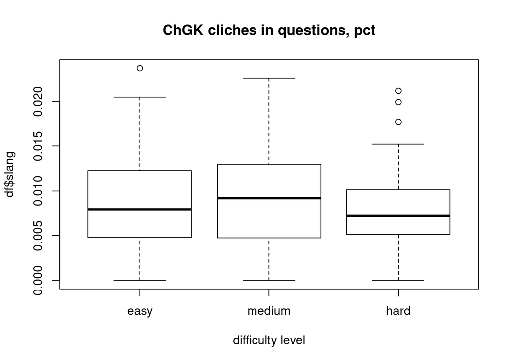

```r
boxplot(df$slang ~ df$levels,
        main="ChGK cliches in questions, pct", xlab="difficulty level")
```

At this moment it seems that the variables `often_aw` (the percentage of frequent words in answers) and `often_an` (the percentage of frequent words in nouns) are the most interesting. This fact corresponds with the quiz player’s intuition: if the word occurs often in the quizzes, the players have more information about the object it represents than about less frequent facts.

**2.2**

**2.2.1** ANOVA To find if there is any significant difference between our three categories, we are performing analysis of variance.

```
H0: There is no statistically significant difference between mean of length of all questions of the set for three levels (means of all levels are equal to each other)
H1: at least two levels are different

H0: There is no statistically significant difference between mean of the Flesch–Kincaid readability score for the questions in the set for three levels
H1: at least two levels are different

H0: There is no statistically significant difference between percentage of the words with high frequency in the questions set for three levels
H1: at least two levels are different

H0: There is no statistically significant difference between percentage of the words with high frequency in the answers set for three levels
H1: at least two levels are different

H0: There is no statistically significant difference between percentage of the nouns with high frequency in the questions set for three levels
H1: at least two levels are different

H0: There is no statistically significant difference between percentage of the nouns with high frequency in the answers set for three levels
H1: at least two levels are different

H0: There is no statistically significant difference between percentage of ChGK cliches in the question set for three levels
H1: at least two levels are different
```

```r
aovFun <- function(x)
{
    summary(aov(x ~ dif_level, data=df))
}

for (x in names(df[,6:12])){
  print((x))
  print(aovFun(df[,x]))
  print('-----------------------------------------------------------')
}
```

```
## [1] "means_len"
##              Df Sum Sq Mean Sq F value Pr(>F)
## dif_level     2    777   388.4    0.79  0.455
## Residuals   207 101733   491.5
## [1] "-----------------------------------------------------------"
## [1] "fk_mean"
##              Df Sum Sq Mean Sq F value Pr(>F)
## dif_level     2     69   34.75   1.908  0.151
## Residuals   207   3770   18.21
## [1] "-----------------------------------------------------------"
## [1] "often_w"
##              Df  Sum Sq   Mean Sq F value Pr(>F)
## dif_level     2 0.00094 0.0004715   1.314  0.271
## Residuals   207 0.07426 0.0003587
## [1] "-----------------------------------------------------------"
## [1] "often_n"
##              Df Sum Sq   Mean Sq F value Pr(>F)
## dif_level     2 0.0029 0.0014507   1.734  0.179
## Residuals   207 0.1732 0.0008369
## [1] "-----------------------------------------------------------"
## [1] "often_aw"
##              Df Sum Sq Mean Sq F value   Pr(>F)
## dif_level     2 0.1442 0.07208   14.46 1.32e-06 ***
## Residuals   207 1.0317 0.00498
## ---
## Signif. codes:  0 '***' 0.001 '**' 0.01 '*' 0.05 '.' 0.1 ' ' 1
## [1] "-----------------------------------------------------------"
## [1] "often_an"
##              Df Sum Sq Mean Sq F value   Pr(>F)
## dif_level     2  0.160 0.07999   11.68 1.57e-05 ***
## Residuals   207  1.418 0.00685
## ---
## Signif. codes:  0 '***' 0.001 '**' 0.01 '*' 0.05 '.' 0.1 ' ' 1
## [1] "-----------------------------------------------------------"
## [1] "slang"
##              Df   Sum Sq   Mean Sq F value Pr(>F)
## dif_level     2 0.000092 4.613e-05   1.768  0.173
## Residuals   207 0.005401 2.609e-05
## [1] "-----------------------------------------------------------"
```

**2.3** Post-hoc test: which levels differs?

To find which levels have statistically significant difference, we should perform TukeyHSD test.  
CI = 95%.

```r
TukeyHSD(aov(often_aw ~ dif_level, data=df), "dif_level")
```

```
##   Tukey multiple comparisons of means
##     95% family-wise confidence level
##
## Fit: aov(formula = often_aw ~ dif_level, data = df)
##
## $dif_level
##                    diff          lwr          upr     p adj
## hard-easy   -0.06414029 -0.092311236 -0.035969335 0.0000006
## medium-easy -0.03020529 -0.058376236 -0.002034335 0.0323282
## medium-hard  0.03393500  0.005764049  0.062105951 0.0135479
```

There is significant difference between all pairs of groups.

```r
TukeyHSD(aov(often_an ~ dif_level, data=df), "dif_level")
```

```
##   Tukey multiple comparisons of means
##     95% family-wise confidence level
##
## Fit: aov(formula = often_an ~ dif_level, data = df)
##
## $dif_level
##                    diff          lwr           upr     p adj
## hard-easy   -0.06759943 -0.100627937 -3.457092e-02 0.0000078
## medium-easy -0.03292986 -0.065958366  9.865148e-05 0.0508798
## medium-hard  0.03466957  0.001641063  6.769808e-02 0.0371484
```

There is significant difference between groups `hard`-`easy` and `medium`-`hard`.  
As for `medium`-`easy` group, the difference is found but its p-value is slightly higher than 0.05.

# 3 Relationship between variables

To investigate correlation and build the model we should represent the factor variable `levels` as numeric (1 for `easy`, 2 for `medium`, 3 for `hard`). We calculate Spearman’s coefficient because it is more robust to outliers.

```r
df$level_nums=as.numeric(df$levels)
```

**3.1**

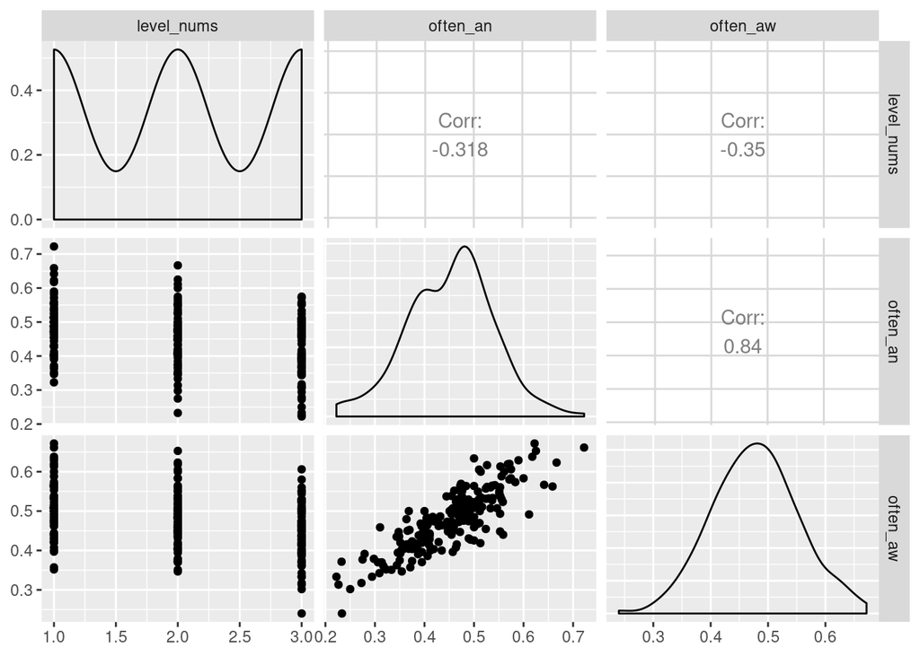

```r
selected <- df %>% select(level_nums, often_an, often_aw)
ggpairs(selected)
```

**3.2** We will check two sets of hypotheses:

```
H0: There is no linear association between the percentage of the words with high frequency in the answers and the set's level
H1: There is linear association between them.

H0: There is no linear association between the percentage of the nouns with high frequency in the answers and the set's level
H1: There is linear association between them.
```

```r
cor.test(as.numeric(df$levels), df$often_an, method = "spearman", exact=FALSE)
```

```
##
##  Spearman's rank correlation rho
##
## data:  as.numeric(df$levels) and df$often_an
## S = 2005246, p-value = 1.028e-05
## alternative hypothesis: true rho is not equal to 0
## sample estimates:
##        rho
## -0.2991848
```

```r
cor.test(as.numeric(df$levels), df$often_aw, method = "spearman", exact=FALSE)
```

```
##
##  Spearman's rank correlation rho
##
## data:  as.numeric(df$levels) and df$often_aw
## S = 2066389, p-value = 4.907e-07
## alternative hypothesis: true rho is not equal to 0
## sample estimates:
##        rho
## -0.3387987
```

Correlation coefficient is -0.3 for `levels` and `often_an` and -0.34 for `level` and `often_aw`, both results are statistically significant at 95% level and shows medium correlation. The correlation coefficients are negative: the higher is the difficulty of set - the lower is the rate of frequent words, in particular nouns.

**3.3** Before model building we split data to train and test and create model using only train set

```r
chgk1 <- sort(sample(nrow(df), nrow(df)*.8))

train<-df[chgk1,]
test<-df[-chgk1,]
```

Check if the data distribution betseen sets is fine:

```r
train %>% group_by(levels) %>%
  summarise(count=n())
```

| levels | count |
| --- | --- |
| easy | 59 |
| medium | 55 |
| hard | 54 |

```r
test %>% group_by(levels) %>%
  summarise(count=n())
```

| levels | count |
| --- | --- |
| easy | 11 |
| medium | 15 |
| hard | 16 |

We build the linear regression models to sescribe the relation between the variables and to predict the difficulty of new sets

```r
model_nouns <- glm(level_nums ~ often_an, data=train)
summary(model_nouns)
```

```
##
## Call:
## glm(formula = level_nums ~ often_an, data = train)
##
## Deviance Residuals:
##     Min       1Q   Median       3Q      Max
## -1.3179  -0.8038   0.0210   0.7669   1.3446
##
## Coefficients:
##             Estimate Std. Error t value Pr(>|t|)
## (Intercept)   3.1767     0.3212   9.890  < 2e-16 ***
## often_an     -2.6623     0.6959  -3.826 0.000184 ***
## ---
## Signif. codes:  0 '***' 0.001 '**' 0.01 '*' 0.05 '.' 0.1 ' ' 1
##
## (Dispersion parameter for gaussian family taken to be 0.6247416)
##
##     Null deviance: 112.85  on 167  degrees of freedom
## Residual deviance: 103.71  on 166  degrees of freedom
## AIC: 401.72
##
## Number of Fisher Scoring iterations: 2
```

```r
mean(round(predict(model_nouns, test, type="response"), 0) == as.numeric(df$levels))
```

```
## [1] 0.3380952
```

Percent of prediction is a 0.005 higher than simple guessing. Not very impressive result.

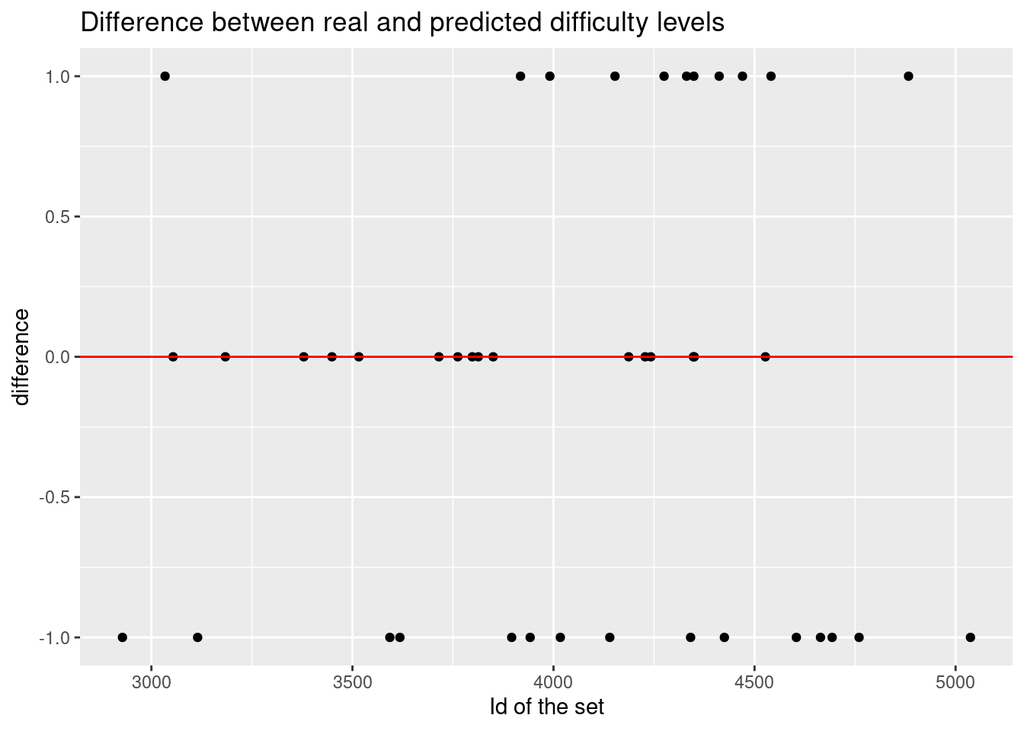

```r
test %>% mutate(pred_nouns = round(predict(model_nouns, test, type="response"), 0)) %>%
  mutate(dif = pred_nouns-level_nums) %>%
  ggplot(aes(x = id, y = dif))+
  geom_point() +
  geom_hline(yintercept = 0, col = "red") +
  ggtitle('Difference between real and predicted difficulty levels') +
  xlab('Id of the set') +
  ylab('difference')
```

```r
model_words <- lm(level_nums ~ often_aw, data=train)
summary(model_words)
```

```
##
## Call:
## lm(formula = level_nums ~ often_aw, data = train)
##
## Residuals:
##      Min       1Q   Median       3Q      Max
## -1.40557 -0.75859  0.01493  0.73277  1.38665
##
## Coefficients:
##             Estimate Std. Error t value Pr(>|t|)
## (Intercept)   3.6273     0.3924   9.243  < 2e-16 ***
## often_aw     -3.4723     0.8126  -4.273 3.24e-05 ***
## ---
## Signif. codes:  0 '***' 0.001 '**' 0.01 '*' 0.05 '.' 0.1 ' ' 1
##
## Residual standard error: 0.7826 on 166 degrees of freedom
## Multiple R-squared:  0.09911,    Adjusted R-squared:  0.09368
## F-statistic: 18.26 on 1 and 166 DF,  p-value: 3.236e-05
```

```r
mean(round(predict(model_words, test, type="response"), 0) == as.numeric(df$levels))
```

```
## [1] 0.3238095
```

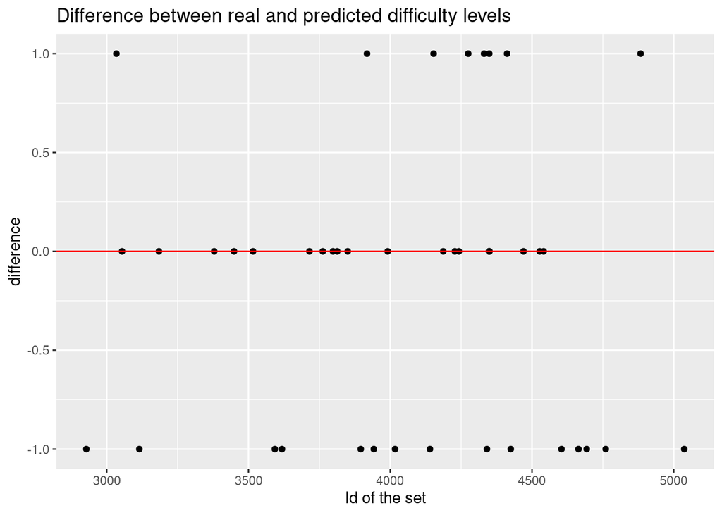

```r
test %>% mutate(pred_words =round(predict(model_words, test, type="response"), 0)) %>%
  mutate(dif = pred_words-level_nums) %>%
  ggplot(aes(x = id, y = dif))+
  geom_point() +
  geom_hline(yintercept = 0, col = "red") +
  ggtitle('Difference between real and predicted difficulty levels') +
  xlab('Id of the set') +
  ylab('difference')
```

Both models doesn’t show satisfying prediction. Maybe looking at the 3 chosen by human levels is oversimplification, and we should look at all range of levels. Let’s briefly check this assumption.

# 4 Brief look at difficulty numbers

Perform the same tests for all difficulty numbers.

```r
cor.test(df$dif_number, df$often_an, method = "spearman", exact=FALSE)
```

```
##
##  Spearman's rank correlation rho
##
## data:  df$dif_number and df$often_an
## S = 2059330, p-value = 7.13e-07
## alternative hypothesis: true rho is not equal to 0
## sample estimates:
##        rho
## -0.3342255
```

```r
cor.test(df$dif_number, df$often_aw, method = "spearman", exact=FALSE)
```

```
##
##  Spearman's rank correlation rho
##
## data:  df$dif_number and df$often_aw
## S = 2085129, p-value = 1.767e-07
## alternative hypothesis: true rho is not equal to 0
## sample estimates:
##        rho
## -0.3509405
```

Correlation coefficient is -0.34 for `dif_number` and `often_an` and -0.35 for `dif_number` and `often_aw`, both results are statistically significant at 95% level and shows medium correlation. The correlation coefficients are negative: the higher is the difficulty of set - the lower is the rate of frequent words, in particular nouns.

```r
model_num_nouns <- lm(dif_number ~ often_an, data=train)
summary(model_num_nouns)
```

```
##
## Call:
## lm(formula = dif_number ~ often_an, data = train)
##
## Residuals:
##     Min      1Q  Median      3Q     Max
## -2.5728 -1.0041 -0.1869  0.7326  4.2522
##
## Coefficients:
##             Estimate Std. Error t value Pr(>|t|)
## (Intercept)   6.4222     0.5353  11.998  < 2e-16 ***
## often_an     -4.7486     1.1597  -4.095 6.59e-05 ***
## ---
## Signif. codes:  0 '***' 0.001 '**' 0.01 '*' 0.05 '.' 0.1 ' ' 1
##
## Residual standard error: 1.317 on 166 degrees of freedom
## Multiple R-squared:  0.09174,    Adjusted R-squared:  0.08627
## F-statistic: 16.77 on 1 and 166 DF,  p-value: 6.587e-05
```

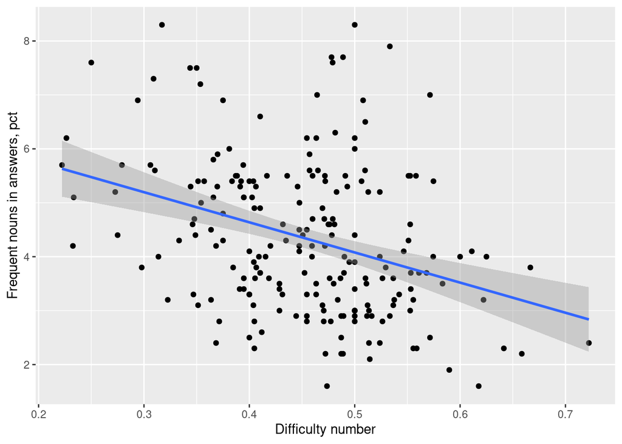

```r
lm_levels <- ggplot(data = df, aes(x = often_an, y = dif_number)) +
              geom_point() +
              labs(x = "Difficulty number",
                   y = "Frequent nouns in answers, pct") +
              geom_smooth(method=lm)

lm_levels
```

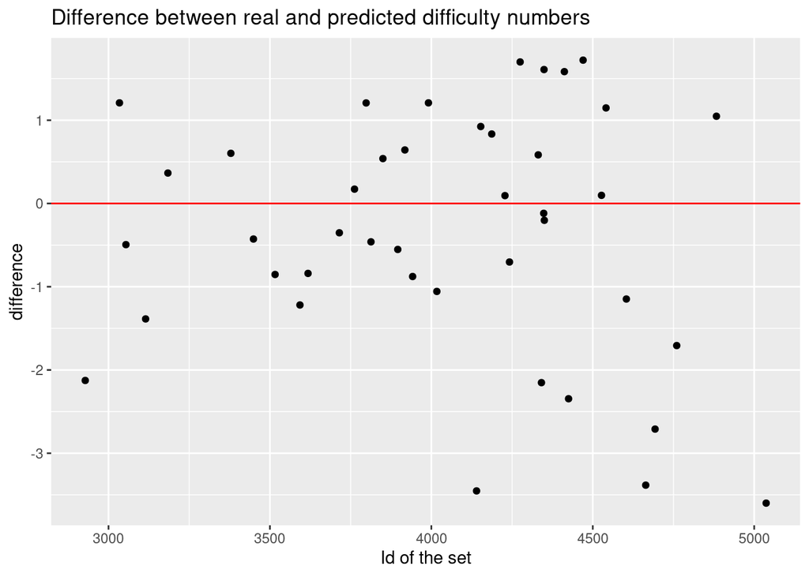

```r
test %>% mutate(pred_num_nouns=predict(model_num_nouns, test, type="response")) %>%
  mutate(dif = pred_num_nouns-dif_number) %>%
  ggplot(aes(x = id, y = dif))+
  geom_point() +
  geom_hline(yintercept = 0, col = "red") +
  ggtitle('Difference between real and predicted difficulty numbers') +
  xlab('Id of the set') +
  ylab('difference')
```

```r
model_num_words <- lm(dif_number ~ often_aw, data=train)
summary(model_num_words)
```

```
##
## Call:
## lm(formula = dif_number ~ often_aw, data = train)
##
## Residuals:
##     Min      1Q  Median      3Q     Max
## -2.1835 -0.9694 -0.1714  0.7438  4.2377
##
## Coefficients:
##             Estimate Std. Error t value Pr(>|t|)
## (Intercept)    7.004      0.659  10.629  < 2e-16 ***
## often_aw      -5.729      1.364  -4.199 4.36e-05 ***
## ---
## Signif. codes:  0 '***' 0.001 '**' 0.01 '*' 0.05 '.' 0.1 ' ' 1
##
## Residual standard error: 1.314 on 166 degrees of freedom
## Multiple R-squared:  0.09602,    Adjusted R-squared:  0.09057
## F-statistic: 17.63 on 1 and 166 DF,  p-value: 4.361e-05
```

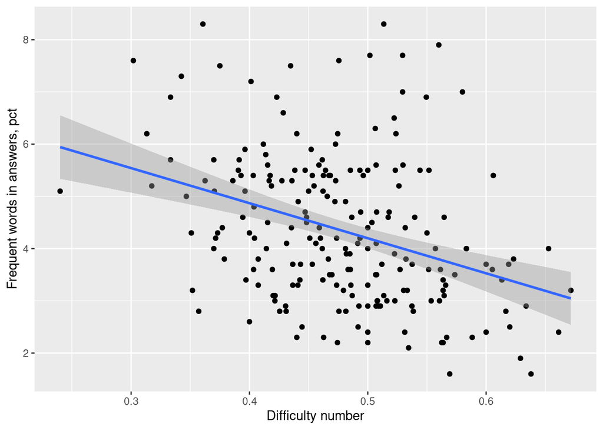

```r
ggplot(data = df, aes(x = often_aw, y = dif_number)) +
              geom_point() +
              labs(x = "Difficulty number",
                   y = "Frequent words in answers, pct") +
              geom_smooth(method=lm)
```

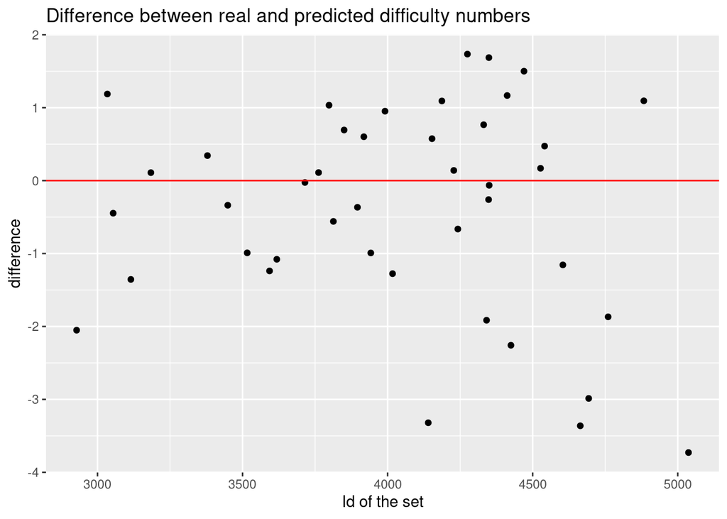

```r
test %>% mutate(pred_num_words=predict(model_num_words, test, type="response")) %>%
  mutate(dif = pred_num_words-dif_number) %>%
  ggplot(aes(x = id, y = dif))+
  geom_point() +
  geom_hline(yintercept = 0, col = "red") +
  ggtitle('Difference between real and predicted difficulty numbers') +
  xlab('Id of the set') +
  ylab('difference')
```

For both models prediction varies and may differ from the truth for more than 2 numbers.

# 5 Conclusions.

During our research we discovered only one type of variables, for which the H0 can be rejected: the percentage of the frequent words/nouns in the ChGK answers.  
It seems that readability metrics do not work for quiz questions. Other lexical characteristics also show no significant difference for the categories.

However, our study has only begun, and our metrics are to be improved. We can run some more readability metrics (just in case), and develop more sophisticated lexical features. It would be interesting to analyse not single tokens, but N-grams, because a lot of answers are fixed expressions (for example, “кот Шрёдингера” or “венок сонетов”). Moreover, some of the difficult fixed expressions consist of easy words: words “конец” and “история” are frequent, but Fukuyama’s book “Конец истории” is not that popular. These problems should be considered in the next works.

It would be also interesting to study the difference not between recent tournaments of different difficulty but between the modern tournaments and tournaments of 1990s. The language of questions has changed a lot since then, for example, slang was less popular (according to the expert’s intuition).

And the last and most ambitious goal is to try to predict the difficulty of the new sets of questions before they would be played and then compare predicted difficulty with actual one. It is unlikely that current version of this instrument can be really useful for ChGK authors but it can be pretty amusing.